# Distributions In-Class Exercise

#### d. Pick some appropriate parameters for your distribution as applied to the transformation scenario and graph the PDF and CDF.

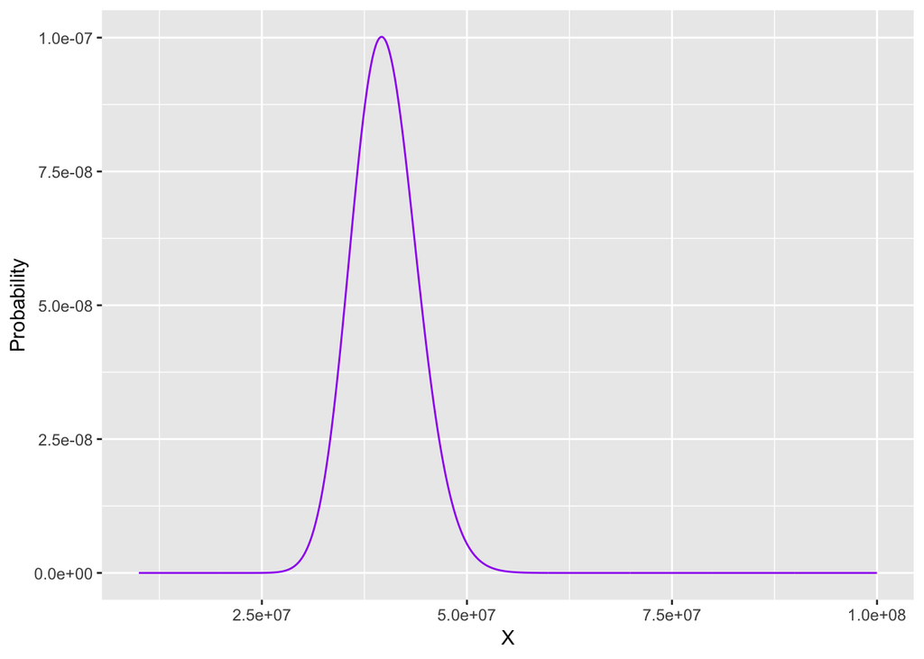

```r
require(ggplot2)

r=100
p=0.0000025
nmax=10^8
nmin=10^7
xmax=nmax-r
xmin=nmin-r
xrange=seq(xmin,xmax,by=100000)

pmf <- dnbinom(xrange,r,p)
pmf.data <- as.data.frame(pmf)
ggplot(pmf.data,aes(x=xrange,y=pmf))+
  geom_line(color="purple")+
  xlab("X")+
  ylab("Probability")
```

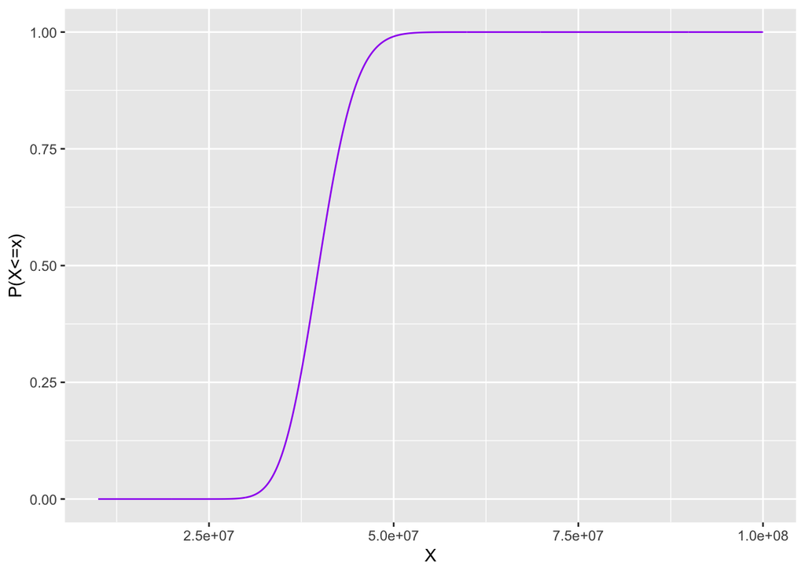

```r
cdf <- pnbinom(xrange,r,p)
cdf.data <- as.data.frame(cdf)
ggplot(cdf.data,aes(x=xrange,y=cdf))+
  geom_line(color="purple")+
  xlab("X")+
  ylab("P(X<=x)")
```

```r
#There is another useful way to use this function. Like what is the #probability of getting 100 or less transformants. This could be #calculated by summing over the range 1:100 in dbinom's size #parameter (r).
```

#### e. Compute a cumulative probability for some appropriate value and describe in words what it means. Be prepared to explain your answer to the class.

```r
cdf2 <- pnbinom(5*10^7,r,p)
cdf2
```

```
## [1] 0.9906215
```

*It means that in the range from 0 to the specified number of cells, the total probability of getting 100 transformants is very close to 1.*

#### f. Identify at least one other distribution that yours relates to and be prepared to discuss the relationship between them. This could be a special case, a limiting case, an approximation, or an inverse CDF (survival) relationship.

*The geometric distribution is identical to the negative binomial distribution when r=1.*

## Poisson

#### Avrami and Marcel

##### Function Summary

$$X \sim POI(\lambda),\ \ E(x) = Var(X) = \lambda$$

$$PDF: \ \ f(x) = P(X = x) = \frac{e^{-\lambda}\lambda^x}{x!}$$

where $X$ is a Poisson random variable and $\lambda$ is the rate at which events occur in a given interval of time (space), i.e. for $t=1$.

The Poisson makes the following assumptions:

- The number of observed events $x \in \{0,1,2,...\}$ is independent in any interval
- Events occur at a constant (random) rate over a set of intervals of time (or space)
- The rate of events is $\lambda > 0$, the *rate constant* per unit interval
- The probability of observing two or more events in the same interval will approach 0 as intervals become smaller

#### a. What is your function? Describe it in terms of the kind of problem that it applies to. Is it discrete or continuous?

*Our function is the prpbability, p, of geting a number, x, of blue cells per plate. A blue cells means the plasmid harboring the gene for beta galactosidase was transformed, and is considered a success. IOur distirbution is discrete, and there are only two possibilites, while cells or blue cells (0 or 1).*

#### b. Describe a question that you can ask with your distribution as applied to the transformation scenario given above.

*Knowing the average number of blue cells per plate, what is the PMF of blue cells per plate within the range of 0:100. Cells that are blue have been succesfully transformed.*

#### c. Describe the parameterization of the equation. What parameters does it take, and what do they mean?

*Lamba, which is a rate of events/time or events/space. We chose events/space because blue white screening works better with space. In other words, you either have blue or white cells (events) on the plate (space). This is the only parameter we need. The possion distirubution will give us the probability of each number of blue cells within on our range based on the lambda parameter.*

#### d. Pick some appropriate parameters for your distribution as applied to the transformation scenario and graph the PDF and CDF.

```r
lambda <- 40 #blue cells per plate
range.vector <- 0:100

# We chose our rate to be 40 blue cells/plate because based on our lab experience, that is usually how many blue cells we've gotten when transforming lac z plasmids.
```

#### e. Compute a cumulative probability for some appropriate value and describe in words what it means. Be prepared to explain your answer to the class.

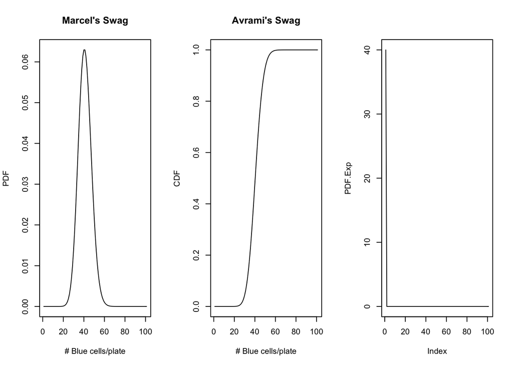

```r
blue.cells.per.plate <- 40
range.vector <- 0:100

par(mfrow = c(1,3))

PDF.Poisson <- dpois(range.vector, lambda = blue.cells.per.plate)
plot(PDF.Poisson, type = "l", main = "Marcel's Swag", xlab = "# Blue cells/plate", ylab = "PDF")

CDF.Poisson <- ppois(range.vector, lambda = blue.cells.per.plate)
plot(CDF.Poisson, type = "l", main = "Avrami's Swag", xlab = "# Blue cells/plate", ylab = "CDF")

PDF.Exp <- dexp(range.vector, rate = blue.cells.per.plate)
plot(PDF.Exp, type = "l")
```

*Between 0 blue cells and 100 blue cells, we have the highest probability of getting 40 blue cells. That probability is still low, lying at 0.06.*

#### f. Identify at least one other distribution that yours relates to and be prepared to discuss the relationship between them. This could be a special case, a limiting case, an approximation, or an inverse CDF (survival) relationship.

*One other distribution that relates for Poisson is exponential, as it can also account for series of events that account for space & time. Exponential can be used for approximations or survival relationships.*

## Normal

#### Zarina and Conor

##### Function Summary

$$X \sim N(\mu,\sigma^2), \ \ where \ \ E(X) = \mu \ \ and \ \ V(X) = \sigma^2$$

$$PDF:\ \ \ f(x) = \frac{1}{\sigma\sqrt{2\pi}} e^{-\frac{1}{2}
\left(\frac{x-\mu}{\sigma}\right)^2}$$

$$CDF: \ \ \ F(x) = \int_{-\infty}^{\infty}
\frac{1}{\sigma\sqrt{2\pi}} e^{-\frac{1}{2}
\left(\frac{x-\mu}{\sigma}\right)^2}dx = 1$$
where

1. Outcomes $x$ are continuous and independent.
2. $x \in \mathbb{R}$
3. $\mu \in \mathbb{R}$
4. $\sigma > 0$

#### a. What is your function? Describe it in terms of the kind of problem that it applies to. Is it discrete or continuous?

*It is the normal distribution, which applies to continuous data. It can describe and model distributions of quantitative traits, such as height and weight.*

#### c. Describe the parameterization of the equation. What parameters does it take, and what do they mean?

- x is the number of outcomes (which are continuous, independent, and real).
- $\mu$ the population average
- $\sigma$ is the standard deviation, which is the square root of the variance.

#### d. Pick some appropriate parameters for your distribution as applied to the transformation scenario and graph the PDF and CDF.

```r
pdf_transformation <- dnorm(x = 0:100, mean = 50, sd = 6)
head(pdf_transformation)
```

```
## [1] 5.534639e-17 2.188992e-16 8.420452e-16 3.150379e-15 1.146375e-14
## [6] 4.057201e-14
```

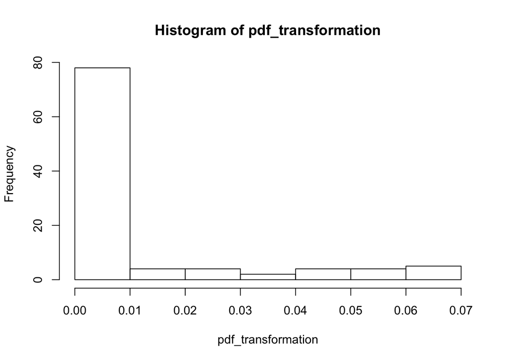

```r
hist(pdf_transformation)
```

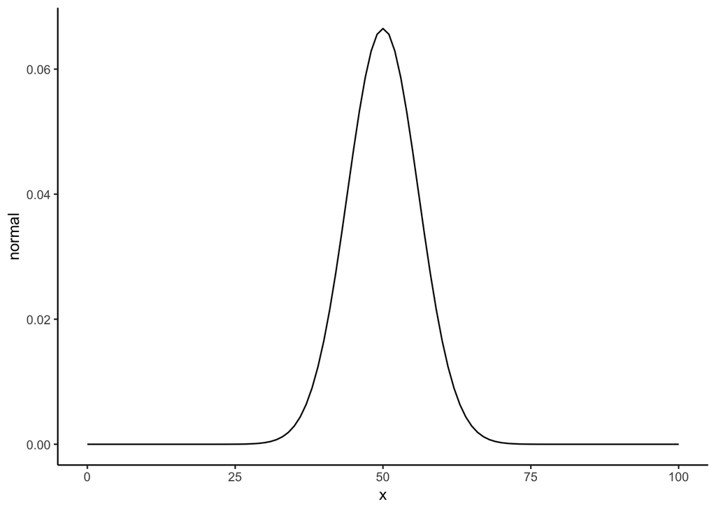

```r
pdf_df <- data.frame(normal = pdf_transformation,
                     X = 0:100)

ggplot(pdf_df,
       aes_string(x= 0:100, y="normal")) +
  theme_classic() +
  geom_line()
```

#### e. Compute a cumulative probability for some appropriate value and describe in words what it means. Be prepared to explain your answer to the class.

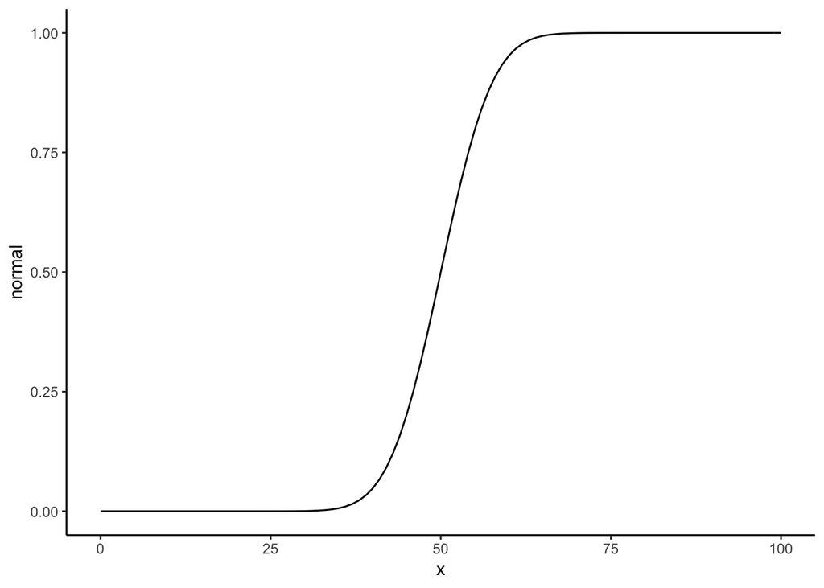

```r
cdf_transformation <- pnorm(q = 0:100, mean = 50, sd = 6)

cdf_df <- data.frame(normal = cdf_transformation,
                     X = 0:100)

ggplot(cdf_df,
       aes_string(x= 0:100, y="normal")) +
  theme_classic() +
  geom_line()
```

*The x axis represents the number of cells successfully transformed, and the y axis is the cumulative probability. For instance, if you are looking for the x number of successfully transformed cells, the cumulative probability is the probability the 0 to x cells are transformed.If you look at x= 50, there is a 50% chance that 50 or fewer cells were transformed.*

#### f. Identify at least one other distribution that yours relates to and be prepared to discuss the relationship between them. This could be a special case, a limiting case, an approximation, or an inverse CDF (survival) relationship.

*Although binomial distribution is discrete, given a large enough n, the distribution of data approximates a normal distribution.*

## Exponential

#### Yingzhen and Veronica

##### Function Summary

$$T \sim EXP(\lambda), \ \ where \ \ E(T) = SD(T) = 1/\lambda,
\ \ Var(T) = (1/\lambda)^2$$

for $\lambda > 0$ and $t \ge 0$.

$$PDF: \ \ f(t) = \lambda e^{-t\lambda}$$
The CDF has a closed form that does not require integration:

$$CDF: \ \ F(t) = \int_0^\infty \lambda e^{-\lambda t}dt = 1 - e^{-t\lambda}$$

### Yinghzen version

#### a. What is your function? Describe it in terms of the kind of problem that it applies to. Is it discrete or continuous?

PDF of the exponential distribution is:
$$f(x)=\lambda e ^ {-\lambda x}$$
Problem: time or space interval between two poisson events. Given $\lambda$ the probability and x the time. It is continuous.

#### b. Describe a question that you can ask with your distribution as applied to the transformation scenario given above.

Distance or of closest pair of clones.

#### c. Describe the parameterization of the equation. What parameters does it take, and what do they mean?

$\lambda$ is the rate of finding another transformed clone within an area of one square centermeter of one clone. For example, $\lambda$ = 0.1 means you can find 0.1 transformed clones within one square centimeter from any clone on average. x the area you need to find another clone.

#### d. Pick some appropriate parameters for your distribution as applied to the transformation scenario and graph the PDF and CDF.

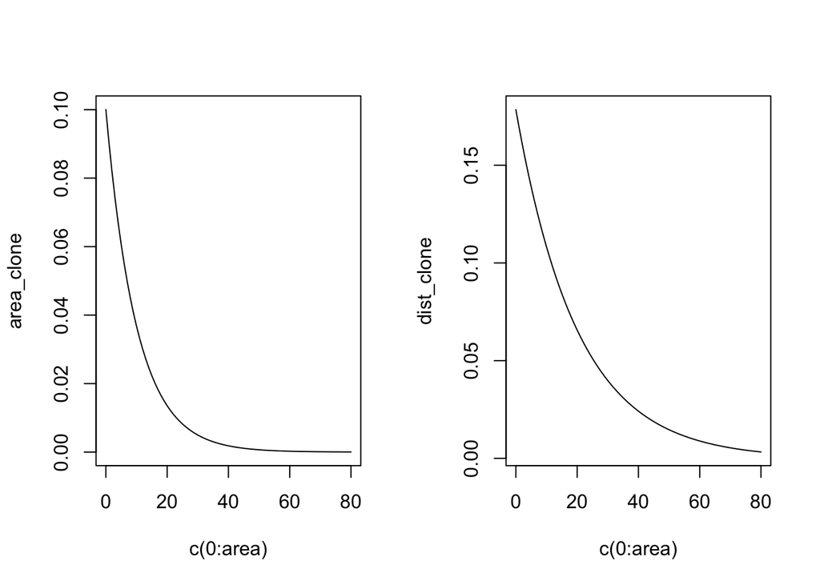

```r
# given a circular dish, with the total number of clones we can know the distribution of transformed clone. Say that we have 100 clones in the dish:
area = 80
rate = 0.1  # rate is lambda
area_clone = dexp(c(0:area), rate)
dist_clone = (area_clone / 3.14) ** 0.5

par(mfrow = c(1,2))
plot(c(0:area), area_clone, type = "l")
plot(c(0:area), dist_clone, type = "l")
```

#### e. Compute a cumulative probability for some appropriate value and describe in words what it means. Be prepared to explain your answer to the class.

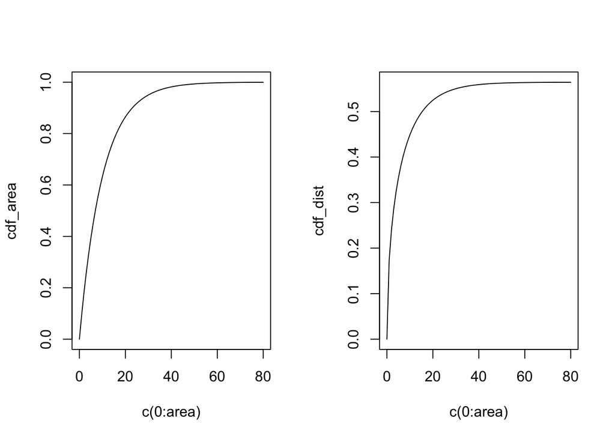

```r
par(mfrow = c(1,2))
cdf_area = pexp(c(0:area), rate)
cdf_dist = (cdf_area / 3.14) ** 0.5
plot(c(0:area), cdf_area, type = "l")
plot(c(0:area), cdf_dist, type = "l")
```

Within certain area or distance, the chance to find next transformed clone. This is depend mainly on the total number of clones per dish, or concentration.

#### f. Identify at least one other distribution that yours relates to and be prepared to discuss the relationship between them. This could be a special case, a limiting case, an approximation, or an inverse CDF (survival) relationship.

Poisson distribution. Poisson describes the number of clones per unit area, while exponential describes the area to find next clone.

### Veronica version

#### a. What is your function? Describe it in terms of the kind of problem that it applies to. Is it discrete or continuous?

$$f(t)=\lambda e^{(-\lambda t)}, \ \ where \ \ \lambda > 0 \ \ and \ \ t > 0$$
continuous describes the amount of time elapsed between events in a poisson point process memoryless

#### b. Describe a question that you can ask with your distribution as applied to the transformation scenario given above.

distance between transformed colonies to their closest transformed neighbor

#### c. Describe the parameterization of the equation. What parameters does it take, and what do they mean?

Takes lambda and t Lambda is the rate or density of transformed colonies, t is time or distance between colonies

#### d. Pick some appropriate parameters for your distribution as applied to the transformation scenario and graph the PDF and CDF.

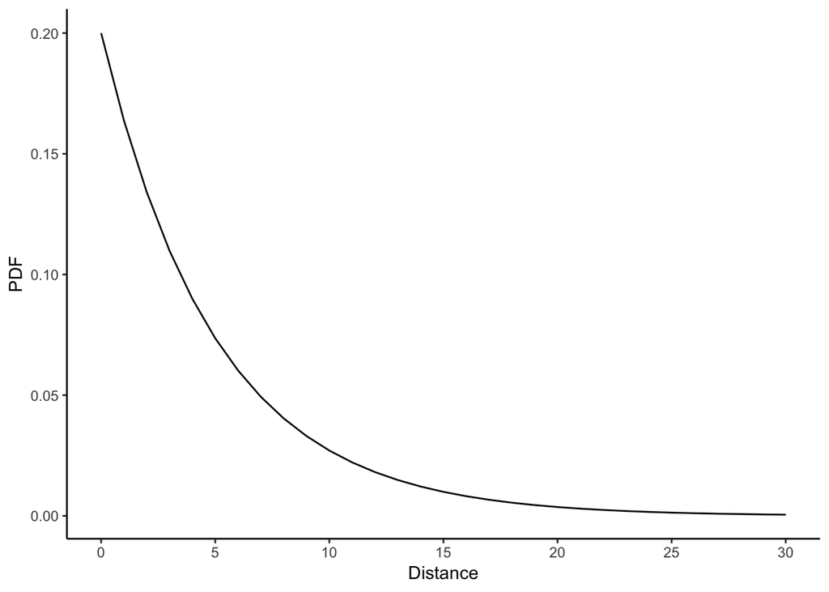

```r
library(ggplot2)
library(scales) # need this for pretty_breaks()

lambda=.2
colony.distance.pdf=dexp(0:30, lambda)
colony.distance.cdf=pexp(0:30, lambda)
colony.distance = data.frame(PDF = colony.distance.pdf, CDF=colony.distance.cdf, Distance=0:30)
ggplot( colony.distance ,aes( x = Distance ,y = PDF )) +
  theme_classic() +
  geom_line() +
  scale_x_continuous(breaks=pretty_breaks())
```

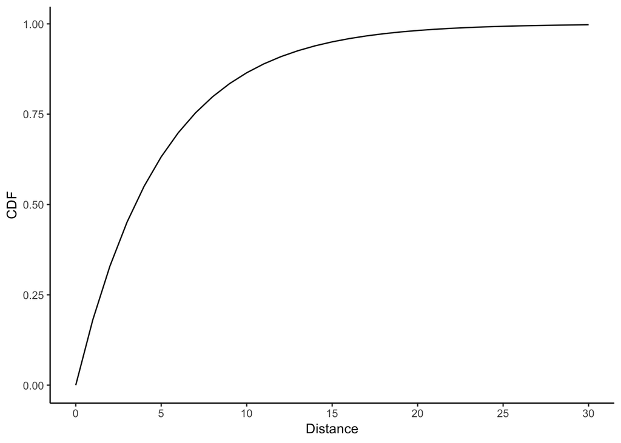

```r
ggplot( colony.distance ,aes( x = Distance ,y = CDF )) +
  theme_classic() +
  geom_line() +
  scale_x_continuous(breaks=pretty_breaks())
```

#### e. Compute a cumulative probability for some appropriate value and describe in words what it means. Be prepared to explain your answer to the class.

```r
colony.distance.cdf
```

```
##  [1] 0.0000000 0.1812692 0.3296800 0.4511884 0.5506710 0.6321206 0.6988058
##  [8] 0.7534030 0.7981035 0.8347011 0.8646647 0.8891968 0.9092820 0.9257264
## [15] 0.9391899 0.9502129 0.9592378 0.9666267 0.9726763 0.9776292 0.9816844
## [22] 0.9850044 0.9877227 0.9899482 0.9917703 0.9932621 0.9944834 0.9954834
## [29] 0.9963021 0.9969724 0.9975212
```

#### f. Identify at least one other distribution that yours relates to and be prepared to discuss the relationship between them. This could be a special case, a limiting case, an approximation, or an inverse CDF (survival) relationship.

continuous version of geometric distribution